# Modern Data Mining, HW 3

Group Member Annie Vo

Group Member Jessica Brown

Group Member Sarah Hayward

Due: 11:59Pm, 2/27, 2022

# 1 Overview

Multiple regression is one of the most popular methods used in statistics as well as in machine learning. We use linear models as a working model for its simplicity and interpretability. It is important that we use domain knowledge as much as we could to determine the form of the response as well as the function format for the factors. Then, when we have many possible features to be included in the working model it is inevitable that we need to choose a best possible model with a sensible criterion. `Cp`, `BIC` and regularizations such as LASSO are introduced. Be aware that if a model selection is done formally or informally, the inferences obtained with the final `lm()` fit may not be valid. Some adjustment will be needed. This last step is beyond the scope of this class. Check the current research line that Linda and collaborators are working on.

This homework consists of two parts: the first one is an excercise (you will feel it being a toy example after the covid case study) to get familiar with model selection skills such as, `Cp` and `BIC`. The main job is a rather involved case study about devastating covid19 pandemic. Please read through the case study first. It is time that group members work together to run a real project. This project is for sure a great one listed in your CV.

For covid case study, the major time and effort would be needed in EDA portion.

## 1.1 Objectives

- Model building process
- Methods
  - Model selection
    - All subsets
    - Forward/Backward
  - Regularization
    - LASSO (L1 penalty)
    - Ridge (L2 penalty)
    - Elastic net
- Understand the criteria
  - `Cp`
  - Testing Errors
  - `BIC`
  - `K fold Cross Validation`
  - `LASSO`
- Packages
  - `lm()`, `Anova`
  - `regsubsets()`
  - `glmnet()` & `cv.glmnet()`

# 2 Review materials

- Study lecture: Model selection
- Study lecture: Regularization
- Study lecture: Multiple regression

Review the code and concepts covered during lectures: multiple regression, model selection and penalized regression through elastic net.

# 3 Case study 1: `ISLR::Auto` data

This will be the last part of the Auto data from ISLR. The original data contains 408 observations about cars. It has some similarity as the Cars data that we use in our lectures. To get the data, first install the package `ISLR`. The data set `Auto` should be loaded automatically. We use this case to go through methods learned so far.

Final modelling question: We want to explore the effects of each feature as best as possible.

1. Preparing variables:
1. You may explore the possibility of variable transformations. We normally do not suggest to transform $x$ for the purpose of interpretation. You may consider to transform $y$ to either correct the violation of the linear model assumptions or if you feel a transformation of $y$ makes more sense from some theory. In this case we suggest you to look into `GPM=1/MPG`. Compare residual plots of MPG or GPM as responses and see which one might yield a more satisfactory patterns.

In addition, can you provide some background knowledge to support the notion: it makes more sense to model `GPM`?

2. You may also explore by adding interactions and higher order terms. The model(s) should be as *parsimonious* (simple) as possible, unless the gain in accuracy is significant from your point of view.
3. Use Mallow’s $C_p$ or BIC to select the model.

```r
head(Auto,3)
```

```
##   mpg cylinders displacement horsepower weight acceleration year origin
## 1  18         8          307        130   3504         12.0   70      1
## 2  15         8          350        165   3693         11.5   70      1
## 3  18         8          318        150   3436         11.0   70      1
##                        name
## 1 chevrolet chevelle malibu
## 2         buick skylark 320
## 3        plymouth satellite
```

```r
dim(Auto)
```

```
## [1] 392   9
```

We have 392 cars (observations) and 9 variables

```r
names(Auto)
```

```
## [1] "mpg"          "cylinders"    "displacement" "horsepower"   "weight"
## [6] "acceleration" "year"         "origin"       "name"
```

```r
str(Auto)
```

```
## 'data.frame':    392 obs. of  9 variables:
##  $ mpg         : num  18 15 18 16 17 15 14 14 14 15 ...
##  $ cylinders   : num  8 8 8 8 8 8 8 8 8 8 ...
##  $ displacement: num  307 350 318 304 302 429 454 440 455 390 ...
##  $ horsepower  : num  130 165 150 150 140 198 220 215 225 190 ...
##  $ weight      : num  3504 3693 3436 3433 3449 ...
##  $ acceleration: num  12 11.5 11 12 10.5 10 9 8.5 10 8.5 ...
##  $ year        : num  70 70 70 70 70 70 70 70 70 70 ...
##  $ origin      : num  1 1 1 1 1 1 1 1 1 1 ...
##  $ name        : Factor w/ 304 levels "amc ambassador brougham",..: 49 36 231 14 161 141 54 223 241 2 ...
```

Here we want to note that all of the variables types are numbers except for name which is a factor that contains 304 different level. This may want to be removed as it would not allow us to perform a plausible regression. There is also little detail that the name of a car can give us to predict the mpg of the car.

We can also see that origin and cylinder have many of the same values appearing, thus we may want to look into those as factors.

```r
summary(Auto)
```

```
##       mpg         cylinders     displacement   horsepower        weight
##  Min.   : 9.0   Min.   :3.00   Min.   : 68   Min.   : 46.0   Min.   :1613
##  1st Qu.:17.0   1st Qu.:4.00   1st Qu.:105   1st Qu.: 75.0   1st Qu.:2225
##  Median :22.8   Median :4.00   Median :151   Median : 93.5   Median :2804
##  Mean   :23.4   Mean   :5.47   Mean   :194   Mean   :104.5   Mean   :2978
##  3rd Qu.:29.0   3rd Qu.:8.00   3rd Qu.:276   3rd Qu.:126.0   3rd Qu.:3615
##  Max.   :46.6   Max.   :8.00   Max.   :455   Max.   :230.0   Max.   :5140
##
##   acceleration       year        origin                     name
##  Min.   : 8.0   Min.   :70   Min.   :1.00   amc matador       :  5
##  1st Qu.:13.8   1st Qu.:73   1st Qu.:1.00   ford pinto        :  5
##  Median :15.5   Median :76   Median :1.00   toyota corolla    :  5
##  Mean   :15.5   Mean   :76   Mean   :1.58   amc gremlin       :  4
##  3rd Qu.:17.0   3rd Qu.:79   3rd Qu.:2.00   amc hornet        :  4
##  Max.   :24.8   Max.   :82   Max.   :3.00   chevrolet chevette:  4
##                                             (Other)           :365
```

```r
sum(is.na(Auto))
```

```
## [1] 0
```

Here we see that there are no missing values in our data set.

Now let’s do some data visualization.

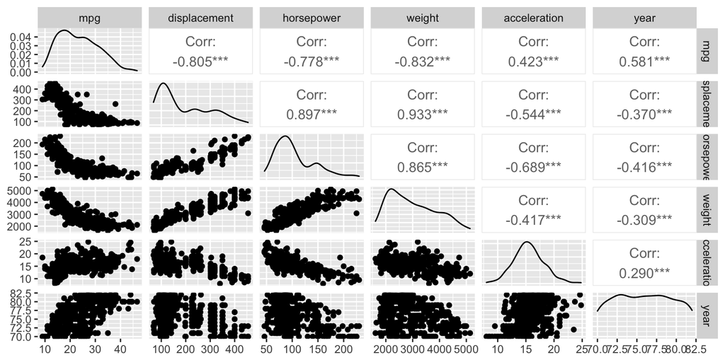

```r
Auto %>%
  select(mpg, displacement, horsepower, weight, acceleration, year) %>%
  ggpairs()
```

Hear we can see the pairwise scatter plots for all numerical variables excluding cylinders and origin as those are likely factor variables and would not be beneficial to display in a scatter plot. Based on these graphs, we can see that the correlation between mpg and displacement/horsepower/weight is very strong and is negative. The relationship between mpg and acceleration/year is moderately strong and positive.

```r
Auto %>% select_if(is.numeric) %>%
  cor()  # pairwise cor's among all quantitative var's
```

```
##                 mpg cylinders displacement horsepower weight acceleration
## mpg           1.000    -0.778       -0.805     -0.778 -0.832        0.423
## cylinders    -0.778     1.000        0.951      0.843  0.898       -0.505
## displacement -0.805     0.951        1.000      0.897  0.933       -0.544
## horsepower   -0.778     0.843        0.897      1.000  0.865       -0.689
## weight       -0.832     0.898        0.933      0.865  1.000       -0.417
## acceleration  0.423    -0.505       -0.544     -0.689 -0.417        1.000
## year          0.581    -0.346       -0.370     -0.416 -0.309        0.290
## origin        0.565    -0.569       -0.615     -0.455 -0.585        0.213
##                year origin
## mpg           0.581  0.565
## cylinders    -0.346 -0.569
## displacement -0.370 -0.615
## horsepower   -0.416 -0.455
## weight       -0.309 -0.585
## acceleration  0.290  0.213
## year          1.000  0.182
## origin        0.182  1.000
```

If we look at the correlations between all of the variables we see that highest two correlated variables is displacement and cylinders which makes sense since those values depend on one another when you are building and engineering the car.

If you regress mpg vs. each variable, one at a time, we can see that weight would yield the highest $R^2$ value as $r^2 = R^2$ is the weight of the car.

Now let’s look at the residual plots for MPG vs GPM to decide which is the best for the regression.

```r
Auto$gpm = 1/Auto$mpg
```

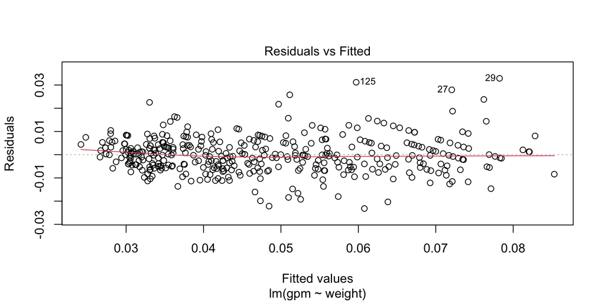

```r
plot(lm(gpm ~ weight, data=Auto), 1)
```

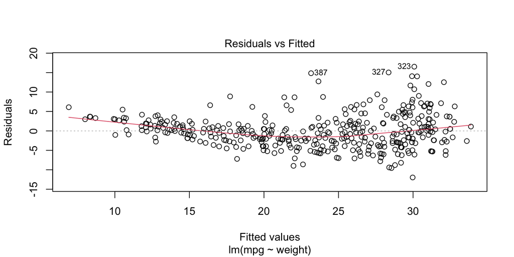

```r
plot(lm(mpg ~ weight, data=Auto), 1)
```

From this graph, we can see that the GPM regression with weight is a better option. For GPM, the residuals are spread randomly around the 0 line. This suggests that the assumption that the relationship is linear is reasonable for this model. The graph also suggests that the variances of the error term are normal, i.e., we have Homoscedasticity.

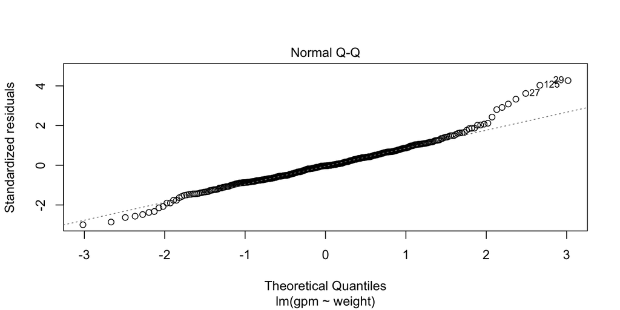

```r
plot(lm(gpm ~ weight, data=Auto), 2)
```

Another reason to not use MPG, is MPG will tell you the range of the car’s gas tank, this means that it could vary significantly between cars as all tank sizes are not the same. GPM is useful when you are comparing different cars as it allows you to better captures the fuel consumption of the car. By using GPM, you can tell how much gas you will need to use for a certain length of driving. This allows for efficiency in comparing different cars to one uniform distance.

Before we begin the model, we are going to look at whether or not we should use cylinders as a numeric or a factor. Clearly origin should be a factor as it is three specific values that represent a categorical variable, however, cylinders in numeric in nature.

First let’s only include the variables that make sense for the regression, i.e., we will not be including names for the regression and we removed MPG as we will be using GPM.

```r
names.exclude <- names(Auto) %in% c("name", "mpg")
Auto2 <- Auto[!names.exclude]
names(Auto2)
```

```
## [1] "cylinders"    "displacement" "horsepower"   "weight"       "acceleration"
## [6] "year"         "origin"       "gpm"
```

We will make origin into a factor here.

```r
Auto2$origin <- as.factor(Auto2$origin)
str(Auto2$origin)
```

```
##  Factor w/ 3 levels "1","2","3": 1 1 1 1 1 1 1 1 1 1 ...
```

Now we will compare the regression for cylinder as a numeric and cylinder as a factor.

```r
fit.cyl.number <- lm(gpm~. , Auto2)
```

```r
Auto2$cylinders <- as.factor(Auto2$cylinders)
fit.cyl.factor <- lm(gpm~. , Auto2)
anova(fit.cyl.number, fit.cyl.factor)
```

```
## Analysis of Variance Table
##
## Model 1: gpm ~ cylinders + displacement + horsepower + weight + acceleration +
##     year + origin
## Model 2: gpm ~ cylinders + displacement + horsepower + weight + acceleration +
##     year + origin
##   Res.Df    RSS Df Sum of Sq    F Pr(>F)
## 1    383 0.0123
## 2    380 0.0117  3  0.000511 5.51  0.001 **
## ---
## Signif. codes:  0 '***' 0.001 '**' 0.01 '*' 0.05 '.' 0.1 ' ' 1
```

Although the variable `cylinders` is numeric in nature, it is highly, non linear. This means that it is more valuable to consider this variable as a factor instead of it’s numeric value. Further looking at the analysis of variance for the two variables, with a null hypothesis that the two different fits are the same, we reject the null hypothesis at a level of 0.01, as the p-value is 0.001. Thus, we get that the two fits are significantly different and from our analysis, it would be beneficial to use cylinders as a factor.

Now with our variables as the correct types,we can begin our model selection process.

```r
names(Auto2)
```

```
## [1] "cylinders"    "displacement" "horsepower"   "weight"       "acceleration"
## [6] "year"         "origin"       "gpm"
```

```r
fit.all <-lm(gpm ~., data=Auto2)
summary(fit.all)
```

```
##
## Call:
## lm(formula = gpm ~ ., data = Auto2)
##
## Residuals:
##       Min        1Q    Median        3Q       Max
## -0.015715 -0.003552 -0.000073  0.002978  0.023612
##
## Coefficients:
##               Estimate Std. Error t value Pr(>|t|)
## (Intercept)   1.05e-01   8.15e-03   12.91  < 2e-16 ***
## cylinders4   -9.36e-03   2.97e-03   -3.16   0.0017 **
## cylinders5   -1.16e-02   4.52e-03   -2.57   0.0106 *
## cylinders6   -5.14e-03   3.27e-03   -1.57   0.1175
## cylinders8   -2.56e-03   3.78e-03   -0.68   0.4992
## displacement -2.69e-05   1.30e-05   -2.08   0.0386 *
## horsepower    1.30e-04   2.37e-05    5.48  7.6e-08 ***
## weight        1.04e-05   1.13e-06    9.21  < 2e-16 ***
## acceleration  4.37e-04   1.67e-04    2.62   0.0092 **
## year         -1.27e-03   8.78e-05  -14.43  < 2e-16 ***
## origin2      -2.25e-03   9.89e-04   -2.27   0.0238 *
## origin3      -2.19e-03   9.46e-04   -2.32   0.0210 *
## ---
## Signif. codes:  0 '***' 0.001 '**' 0.01 '*' 0.05 '.' 0.1 ' ' 1
##
## Residual standard error: 0.00556 on 380 degrees of freedom
## Multiple R-squared:  0.892,  Adjusted R-squared:  0.888
## F-statistic:  284 on 11 and 380 DF,  p-value: <2e-16
```

```r
fit.exh <- regsubsets(gpm ~., Auto2 , nvmax=11, method="exhaustive")
```

```r
summary(fit.exh)
```

```
## Subset selection object
## Call: regsubsets.formula(gpm ~ ., Auto2, nvmax = 11, method = "exhaustive")
## 11 Variables  (and intercept)
##              Forced in Forced out
## cylinders4       FALSE      FALSE
## cylinders5       FALSE      FALSE
## cylinders6       FALSE      FALSE
## cylinders8       FALSE      FALSE
## displacement     FALSE      FALSE
## horsepower       FALSE      FALSE
## weight           FALSE      FALSE
## acceleration     FALSE      FALSE
## year             FALSE      FALSE
## origin2          FALSE      FALSE
## origin3          FALSE      FALSE
## 1 subsets of each size up to 11
## Selection Algorithm: exhaustive
##           cylinders4 cylinders5 cylinders6 cylinders8 displacement horsepower
## 1  ( 1 )  " "        " "        " "        " "        " "          " "
## 2  ( 1 )  " "        " "        " "        " "        " "          " "
## 3  ( 1 )  " "        " "        " "        " "        " "          "*"
## 4  ( 1 )  "*"        " "        " "        " "        " "          "*"
## 5  ( 1 )  "*"        " "        " "        " "        " "          "*"
## 6  ( 1 )  "*"        "*"        " "        " "        " "          "*"
## 7  ( 1 )  "*"        "*"        "*"        " "        " "          "*"
## 8  ( 1 )  "*"        "*"        "*"        " "        "*"          "*"
## 9  ( 1 )  "*"        "*"        "*"        " "        "*"          "*"
## 10  ( 1 ) "*"        "*"        "*"        " "        "*"          "*"
## 11  ( 1 ) "*"        "*"        "*"        "*"        "*"          "*"
##           weight acceleration year origin2 origin3
## 1  ( 1 )  "*"    " "          " "  " "     " "
## 2  ( 1 )  "*"    " "          "*"  " "     " "
## 3  ( 1 )  "*"    " "          "*"  " "     " "
## 4  ( 1 )  "*"    " "          "*"  " "     " "
## 5  ( 1 )  "*"    "*"          "*"  " "     " "
## 6  ( 1 )  "*"    "*"          "*"  " "     " "
## 7  ( 1 )  "*"    "*"          "*"  " "     " "
## 8  ( 1 )  "*"    "*"          "*"  " "     " "
## 9  ( 1 )  "*"    "*"          "*"  "*"     " "
## 10  ( 1 ) "*"    "*"          "*"  "*"     "*"
## 11  ( 1 ) "*"    "*"          "*"  "*"     "*"
```

```r
f.e <- summary(fit.exh)
names(f.e)
```

```
## [1] "which"  "rsq"    "rss"    "adjr2"  "cp"     "bic"    "outmat" "obj"
```

```r
str(f.e)
```

[output not shown]

We want to use the Cp criterion to determine which of the models has the lowest prediction error.

```r
f.e$cp
```

```
##  [1] 371.1  59.2  33.2  23.2  19.3  16.3  15.7  13.8  13.9  10.5  12.0
```

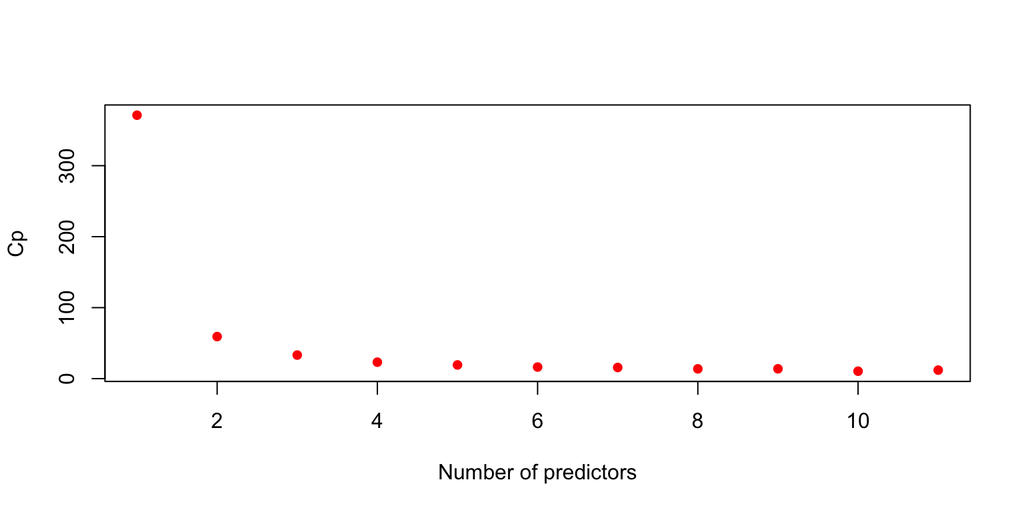

```r
plot(f.e$cp, xlab="Number of predictors",
     ylab="Cp", col="red", pch=16)
```

Based on the Cp values it appears that the model with the lowest Cp is the one that has all 10 variables. The Cp for that model has a value of 10.5. Let’s look at that model.

```r
coef(fit.exh,10)
```

```
##  (Intercept)   cylinders4   cylinders5   cylinders6 displacement   horsepower
##     1.04e-01    -7.73e-03    -9.77e-03    -3.08e-03    -3.16e-05     1.31e-04
##       weight acceleration         year      origin2      origin3
##     1.05e-05     4.30e-04    -1.27e-03    -2.31e-03    -2.20e-03
```

```r
opt.size <- which.min(f.e$cp)
opt.size
```

```
## [1] 10
```

Let’s look at which variables are selected

```r
fit.exh.var <- f.e$which
fit.exh.var[opt.size,]
```

```
##  (Intercept)   cylinders4   cylinders5   cylinders6   cylinders8 displacement
##         TRUE         TRUE         TRUE         TRUE        FALSE         TRUE
##   horsepower       weight acceleration         year      origin2      origin3
##         TRUE         TRUE         TRUE         TRUE         TRUE         TRUE
```

We can see here that the variable this model would remove is cylinders8, however, this is part of a factor variable and we cannot just removed that one part, so let’s run another model that excludes the entire cylinders variable and compart the prediction errors.

```r
fit.exh2 <- regsubsets(gpm ~ displacement + horsepower + weight + acceleration + year + origin, Auto2 , nvmax=7, method="exhaustive")
```

```r
summary(fit.exh2)
```

```
## Subset selection object
## Call: regsubsets.formula(gpm ~ displacement + horsepower + weight +
##     acceleration + year + origin, Auto2, nvmax = 7, method = "exhaustive")
## 7 Variables  (and intercept)
##              Forced in Forced out
## displacement     FALSE      FALSE
## horsepower       FALSE      FALSE
## weight           FALSE      FALSE
## acceleration     FALSE      FALSE
## year             FALSE      FALSE
## origin2          FALSE      FALSE
## origin3          FALSE      FALSE
## 1 subsets of each size up to 7
## Selection Algorithm: exhaustive
##          displacement horsepower weight acceleration year origin2 origin3
## 1  ( 1 ) " "          " "        "*"    " "          " "  " "     " "
## 2  ( 1 ) " "          " "        "*"    " "          "*"  " "     " "
## 3  ( 1 ) " "          "*"        "*"    " "          "*"  " "     " "
## 4  ( 1 ) " "          "*"        "*"    " "          "*"  "*"     " "
## 5  ( 1 ) " "          "*"        "*"    "*"          "*"  "*"     " "
## 6  ( 1 ) " "          "*"        "*"    "*"          "*"  "*"     "*"
## 7  ( 1 ) "*"          "*"        "*"    "*"          "*"  "*"     "*"
```

```r
f.e2 <- summary(fit.exh2)
names(f.e2)
```

```
## [1] "which"  "rsq"    "rss"    "adjr2"  "cp"     "bic"    "outmat" "obj"
```

```r
str(f.e2)
```

[output not shown]

```r
f.e2$cp
```

```
## [1] 333.04  36.89  12.26   9.52   7.59   6.83   8.00
```

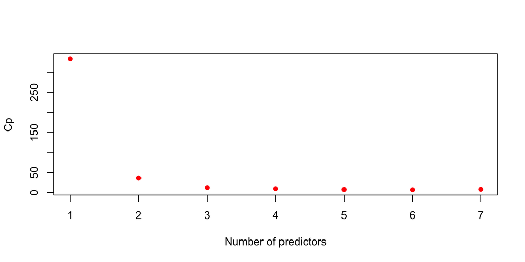

```r
plot(f.e2$cp, xlab="Number of predictors",
     ylab="Cp", col="red", pch=16)
```

Here we see that the lowest Cp value is 6.83.

Let’s find the model with the optimal size.

```r
opt.size <- which.min(f.e2$cp)
opt.size
```

```
## [1] 6
```

```r
fit.exh.var2 <- f.e2$which
fit.exh.var2[opt.size,]
```

```
##  (Intercept) displacement   horsepower       weight acceleration         year
##         TRUE        FALSE         TRUE         TRUE         TRUE         TRUE
##      origin2      origin3
##         TRUE         TRUE
```

So the optimal model here is the one with 6 variables as it has the lowest prediction error. We see that this model does not include displacement.

Let’s make one more model that excludes displacement but includes cylinders and see what the Cp for that would be.

```r
fit3 <- regsubsets(gpm ~ cylinders + horsepower + weight + acceleration + year + origin, Auto2 , nvmax=11, method="exhaustive")
summary(fit3)
```

```
## Subset selection object
## Call: regsubsets.formula(gpm ~ cylinders + horsepower + weight + acceleration +
##     year + origin, Auto2, nvmax = 11, method = "exhaustive")
## 10 Variables  (and intercept)
##              Forced in Forced out
## cylinders4       FALSE      FALSE
## cylinders5       FALSE      FALSE
## cylinders6       FALSE      FALSE
## cylinders8       FALSE      FALSE
## horsepower       FALSE      FALSE
## weight           FALSE      FALSE
## acceleration     FALSE      FALSE
## year             FALSE      FALSE
## origin2          FALSE      FALSE
## origin3          FALSE      FALSE
## 1 subsets of each size up to 10
## Selection Algorithm: exhaustive
##           cylinders4 cylinders5 cylinders6 cylinders8 horsepower weight
## 1  ( 1 )  " "        " "        " "        " "        " "        "*"
## 2  ( 1 )  " "        " "        " "        " "        " "        "*"
## 3  ( 1 )  " "        " "        " "        " "        "*"        "*"
## 4  ( 1 )  "*"        " "        " "        " "        "*"        "*"
## 5  ( 1 )  "*"        " "        " "        " "        "*"        "*"
## 6  ( 1 )  "*"        "*"        " "        " "        "*"        "*"
## 7  ( 1 )  "*"        "*"        "*"        " "        "*"        "*"
## 8  ( 1 )  "*"        "*"        "*"        "*"        "*"        "*"
## 9  ( 1 )  "*"        "*"        "*"        "*"        "*"        "*"
## 10  ( 1 ) "*"        "*"        "*"        "*"        "*"        "*"
##           acceleration year origin2 origin3
## 1  ( 1 )  " "          " "  " "     " "
## 2  ( 1 )  " "          "*"  " "     " "
## 3  ( 1 )  " "          "*"  " "     " "
## 4  ( 1 )  " "          "*"  " "     " "
## 5  ( 1 )  "*"          "*"  " "     " "
## 6  ( 1 )  "*"          "*"  " "     " "
## 7  ( 1 )  "*"          "*"  " "     " "
## 8  ( 1 )  "*"          "*"  " "     " "
## 9  ( 1 )  "*"          "*"  " "     "*"
## 10  ( 1 ) "*"          "*"  "*"     "*"
```

```r
fe.3 <- summary(fit3)
fe.3$cp
```

```
##  [1] 364.6  55.4  29.6  19.7  15.9  12.9  12.3  11.1  11.7  11.0
```

We can see here that none of the Cp values are less than the model that excluded displacement and cylinders.

2. Describe the final model and its accuracy. Include diagnostic plots with particular focus on the model residuals.
- Summarize the effects found.
- Predict the `mpg` of a car that is: built in 1983, in the US, red, 180 inches long, 8 cylinders, 350 displacement, 260 as horsepower, and weighs 4,000 pounds. Give a 95% CI.
- Any suggestions as to how to improve the quality of the study?

The final model we selected predicts GPM for a car using horsepower, weight, acceleration, year, and origin. In our model we have origin as a factor variable since the variable is non-linear and are not of significance in a linear model if kept as numerical values. We used the all subsets method to select a model with the lowest prediction area using the Cp criterion. The Cp for our final model was equal to 6.83.

```r
final.fit <- lm(gpm~horsepower + weight + acceleration + year + origin, Auto2)
summary(final.fit)
```

```
##
## Call:
## lm(formula = gpm ~ horsepower + weight + acceleration + year +
##     origin, data = Auto2)
##
## Residuals:
##       Min        1Q    Median        3Q       Max
## -0.016354 -0.003342 -0.000251  0.002865  0.024453
##
## Coefficients:
##               Estimate Std. Error t value Pr(>|t|)
## (Intercept)   9.72e-02   7.90e-03   12.31  < 2e-16 ***
## horsepower    1.14e-04   2.25e-05    5.05  6.9e-07 ***
## weight        1.10e-05   8.58e-07   12.79  < 2e-16 ***
## acceleration  3.48e-04   1.67e-04    2.09   0.0375 *
## year         -1.30e-03   8.82e-05  -14.71  < 2e-16 ***
## origin2      -2.48e-03   8.89e-04   -2.78   0.0056 **
## origin3      -1.49e-03   8.98e-04   -1.66   0.0975 .
## ---
## Signif. codes:  0 '***' 0.001 '**' 0.01 '*' 0.05 '.' 0.1 ' ' 1
##
## Residual standard error: 0.0057 on 385 degrees of freedom
## Multiple R-squared:  0.884,  Adjusted R-squared:  0.883
## F-statistic:  491 on 6 and 385 DF,  p-value: <2e-16
```

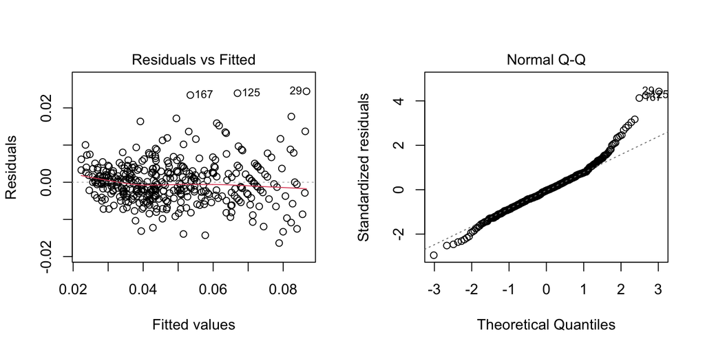

```r
par(mfrow=c(1,2))
plot(final.fit, 1)
plot(final.fit, 2)
```

Note: we aren’t given acceleration, so I will remove that variable.

```r
final.fit0 <- lm(gpm~horsepower + weight  + year + origin, Auto2)
predict(final.fit0, newdata = data.frame(horsepower = 260, weight = 4000, year = 83, origin = as.factor(1)), interval = "confidence", level = 0.95)
```

```
##     fit    lwr    upr
## 1 0.064 0.0595 0.0684
```

```r
1/0.0595
```

```
## [1] 16.8
```

```r
1/0.0684
```

```
## [1] 14.6
```

The confidence interval for the car with the above specifications is [0.0595 GPM, 0.0684 GPM] or [14.6 mpg, 16.8 mpg] . If an infinite number of samples were drawn from the same population of this car and a 95% CI calculated for each sample, we would expect the population mean to be found within 95% of these CIs. We also can note that the confidence interval is narrower as the prediction interval has an added uncertainty of predicting the exact value rather than the mean value.

In the future, it may be beneficial to run the model using cylinders in a different way as the variable could be more significant based on whether it is a factor or a numerical variable. Potentially exploring R packages to figure this out could be beneficial as well. Further, in the future it could be interesting to look at more cars that are from the same company. For instance, most of the cars were from different companies which could impact the car in a different varaible we cannot record. Further, most of the cars are from the later 1900s. It would be interesting to see if anything has changed with new technologies.

# 4 Case study 2: COVID

See covid_case_study.Rmd.